# Analysis of Excercise Monitoring Data

O Soyemi

### Executive Summary:

#### A machine learning model to predict the excercise qualtity using accelerometer measurements from 6 volunteer subjects during controlled excersises. A Random Forest classification model for predicting 5 possible levels of exercise quality (1 good, 4 bad) was developed using additional bootstrap aggregation beyond that which is intrinsic to Random Forest modeling - i.e. double bootstrap analysis, which is likely an overkill. The aggregated model produced a 99% clasification accuracy with the training dataset. The model was applied to data acquired from 20 test cases and 100% of all the test cases were correctly classified by exercise quality.

#### The model training and test data was downloaded from web and loaded into the R working environment as follows:

```r
training <- read.csv('train.csv')
testing <- read.csv('test.csv')
```

### Feature Selection

#### The training set data consists of 19622 measurements acquired across 160 variables on 6 male subjects from 20-28 years old (1). The variables include the dependent variable (“classe”) describing exercise quality (A-E). The remaining 159 variables contain variants of accelerometer measurements from the arm, forearm, dumbbell and exercise belt; as well as time. The following steps were taken in selecting the best combination of predictors for modeling “classe”

#### First all the variables containing incomplete data were removed

```r
library("caret")
cname <- colnames(training)
colnames(testing) <- cname
ytrain <- training$classe
ytest <- testing$classe

# Remove the variable "classe" from training and test sets
training <- training[,cname!="classe"]
testing <- testing[,cname!="classe"]
cname <- cname[cname!="classe"]

h <- logical()
for (j in 1:dim(training)[2]){
 h <- rbind(h,!("TRUE" %in% is.na(training[,j])))
}

training <- training[,cname[h]]
testing <- testing[,cname[h]]
cname <- cname[h]
```

#### Next, near zeros variance predictors were identified and removed.

```r
nz <- nearZeroVar(training,saveMetrics=TRUE)
training <- training[,nz$nzv==FALSE]
testing <- testing[,nz$nzv==FALSE]
cname <- cname[nz$nzv==FALSE]
```

#### Finally all the time-related variables were removed because no significant time trends were identified in the remaining predictors.

```r
training <- training[,-(1:6)] # Remove time related variables
testing <- testing[,-(1:6)]
cname <- cname[-(1:6)]
```

```r
# Data fram listing variables by exercise type
g <- data.frame(cbind(cname[grepl('_belt',cname)],
cname[grepl('_dumbbell',cname)],
cname[grepl('_forearm',cname)],
cname[grepl('_arm',cname)]))
colnames(g) <- c("Belt","Dumbbell","Forearm","Arm")
```

### Machine-Learning Model

#### Realizing that there are multiple machine-learning algorithm options for this dataset, the random forest algorithm was chosen to model this data. Because of the difference in the magnitude of the various predictors, the only preprocessing applied to the data was scaling and centering.

```r
# Preprocess training set
preObj <- preProcess(training ,method=c("center","scale"))
trainingH <- predict(preObj,training)
```

#### The number of variables that are randomly sampled at each split was set to sqrt(#predictors) or sqrt(52) which is ~ 7 (this is the default for this algorithm, and it works well enough. The optimum number of trees was optimized as follows:

```r
library("randomForest")
```

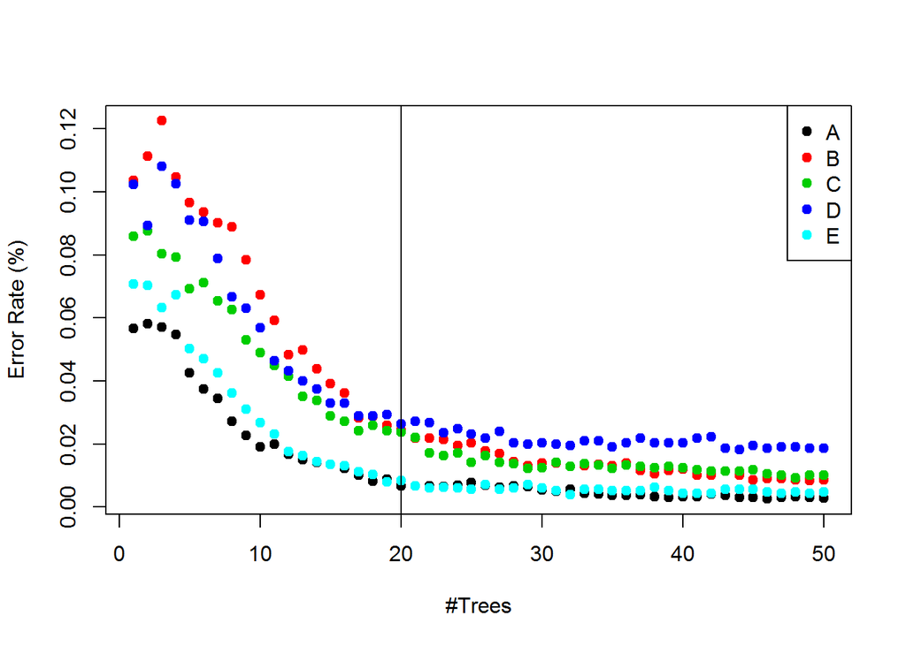

```r
# optimize number of classification trees
ix <- createDataPartition(y=ytrain,p=0.7,list=FALSE)
initfit <- randomForest(trainingH[ix,],y=ytrain[ix],
       xtest=trainingH[-ix,],ytest=ytrain[-ix],ntree=50)

f <- initfit$err.rate[,colnames(initfit$err.rate) != "OOB"]
matplot(f, type = "p",pch=19,col = 1:5,ylab="Error Rate (%)",xlab='#Trees') #plot
legend("topright", legend = c("A","B","C","D","E"), col=1:5, pch=19)
abline(v=20)
```

#### Based on the plotted results of error rate versus number of trees, 20 trees was found to be optimum for the 5 classes. Next an aggregated bootstrap model with 20 trees and 7 randomly sampled variables for each bootstrap samples (Number of bootstrap (re)samples = 20)

```r
iter = 20 # Number of bootstrap samples
testingH <- predict(preObj,testing) # Pre-process data from 20 test subjects
acc <- matrix(0,nrow=iter) # Initialize matrix of aggregated accuracy data
ypred <- matrix(0,nrow=20,ncol=iter) # Initialize matrix of class assignments for each of the 20 test samples
SenSpe <- matrix(0,nrow=5,ncol=2) # Initialize matrix of aggregated Sensitivity/Specificity per class

for (i in 1:iter){
  ix <- createDataPartition(y=ytrain,p=0.6,list=FALSE) # generate fresh partitions
  fit <- randomForest(trainingH[ix,],y=ytrain[ix],ntree=20)
  ypred[i,] <- predict(fit,testingH)
  cp <- confusionMatrix(table(ytrain[-ix],predict(fit,trainingH[-ix,])))
  SenSpe <- SenSpe + as.matrix(cp$byClass[,1:2])
  acc[i] <- as.numeric(cp$overall[1]) # accuracy
}
```

#### Next, the aggregated model metrics (sensitivity and specficity for each of the 5 classes and the classification accuracy) were estimated.

#### Aggregate Sensitivity and Specificity:

```r
SenSpe <- SenSpe/iter
SenSpe
```

```
##          Sensitivity Specificity
## Class: A   0.9945981   0.9989302
## Class: B   0.9887924   0.9968266
## Class: C   0.9777392   0.9971624
## Class: D   0.9914539   0.9966068
## Class: E   0.9978113   0.9988844
```

#### Aggregate accuracy in percent:

```r
acc <- 100*mean(as.numeric(acc))
acc
```

```
## [1] 99.05812
```

#### Confusion Matrix (Final bootstrap model only)

```r
fit$confusion
```

```
##      A    B    C    D    E class.error
## A 3313   15    8    9    3  0.01045400
## B   36 2184   38   15    4  0.04084321
## C    4   36 1985   25    4  0.03359299
## D    5    2   42 1875    6  0.02849741
## E    3   11    7   11 2133  0.01478060
```

#### Finally, the class assignments from for each of the 20 test samples was determine from the aggregate model via majority vote:

```r
library("plyr")
c <- unique(ytrain)
r <- as.numeric(count(ypred))[1:20]
results <- c[r] # class assignments for 20 test samples
```

#### The independent model test yielded results in which the exercise qualilty for each of the 20 test subjects was correctly identified i.e. 100% test accuracy.

### REFERENCES

#### (1) Velloso, E.; Bulling, A.; Gellersen, H.; Ugulino, W.; Fuks, H. Qualitative Activity Recognition of Weight Lifting Exercises. Proceedings of 4th International Conference in Cooperation with SIGCHI (Augmented Human ’13) . Stuttgart, Germany: ACM SIGCHI, 2013.